# Workshop part 2

For the second half of the workshop, we’re going to be working on a bigger piece of analysis. The goal is to turn this in to a manuscript.

# Research question

Working with Anna, Anca, and Joanna, the following research question was developed:

What are the clinical traits associated with having a stool Xpert Ultra trace result?

# Set-up

Start by reading in the data. This is the same data that we’ve been using for the pre-workshop activities, with a few additional columns.

```r
data <- read.csv("C:/Users/u249135/OneDrive - Baylor College of Medicine/Teaching Materials/R-workshop/Workshop/Stool4TB Database for Abi.csv")
```

```r
### Let's start by taking a look at the column names of the data
colnames(data)
```

```
##  [1] "record_id"              "redcap_event_name"      "rf_country"
##  [4] "rf_enroll_date"         "rf_age_calculated"      "rf_age"
##  [7] "rf_dob"                 "rf_gender"              "rf_race"
## [10] "rf_enrollocation"       "bf_hivstatus"           "bf_category"
## [13] "bf_weight"              "bf_height"              "bf_respiratoryrate"
## [16] "bf_heartrate"           "bf_startedatt"          "ps_child_casetype"
## [19] "ps_adult_casetype"      "pe_stoolxpertultraperf" "bf_cd4last6month"
## [22] "bf_recentcd4"           "bf_cd4perfomed"         "bf_cd4result"
## [25] "bf_viraloadlast6month"  "bf_recentviraload"      "bf_viraloadperf"
## [28] "df_viraloadresult"      "pe_stoolxpertresult"    "pe_xpertrifamp2"
## [31] "pe_stoomtbqpcr"         "pe_stoomtbqpcresul"     "pe_stoolsemiresult"
## [34] "pe_xpertultra"          "pe_finalculturesult"    "pe_finalculturesult2"
## [37] "pe_xpertresult"         "pe_xpertrifamp"         "pe_xpertsemiqualresult"
## [40] "pe_xpertperformed"      "pe_xpertultraresul"     "pe_xpertsemiresul"
## [43] "pe_lamresult"           "po_completetpt"         "po_tbmonitoringout"
## [46] "po_ttoutcome"
```

We’re going to be using a few packages that we’ve learned today, so read in the `dplyr`, `ggplot2`, and `lubridate` packages.

```r
library(tidyverse)
library(lubridate)
```

We will also use a few new packages today. Please install a few additional packages.

```r
### install.packages("GGally")
### install.packages("broom")
### install.packages("car")
```

```r
library(GGally)
library(broom)
library(car)
```

For the analysis question, we are interested in the stool Xpert Ultra trace results. So to start, let’s filter to all participants who have a positive stool Xpert Ultra result.

```r
data <- data%>%
  ### Filter to all participants at baseline
  filter(redcap_event_name == "Baseline")%>%
  ### Filter to those with a positive stool Xpert Ultra result
  filter(pe_stoolxpertresult == "MTB Detected")
```

Let’s take a peek at the semi-quantitative results of the stool Xpert Ultra test:

```r
table(data$pe_stoolsemiresult, exclude = NULL)%>%
  addmargins()
```

```
##
##      Low   Medium    Trace Very low      Sum
##       12        3       57       17       89
```

Create a variable with whether or not a participant has a stool Xpert Ultra trace result.

```r
data <- data%>%
  ### Create a variable that is "Trace" if the semi-quantitative value is "Trace" and "Not Trace" otherwise
  mutate(stool_semiquant_bin = ifelse(pe_stoolsemiresult == "Trace", "Trace", "Not Trace"))
```

# Where to start

We are going to build a **logistic regression model**.

Logistic regression models are used to predict an outcome with **2 levels**. In our case, we want to predict whether a stool Xpert Ultra will be trace or not.

We are going to use other variables in the data to make an informed prediction.

# Create a few variables

```r
### BMI is not a variable in the data, but weight and height are
data <- data%>%
  ### Create a variable for BMI

  ### Height is in centimeters, so divide by 100 to convert to meters
  mutate(bmi = bf_weight / ((bf_height / 100)^2))
```

```r
### Create a variable for age
### This should be familiar - we did this in the dplyr assignment

data <- data%>%
  ### Convert the dates to a date data type
  mutate(rf_enroll_date = ymd(rf_enroll_date))%>%
  mutate(rf_dob = ymd(rf_dob))%>%
  ### Find the difference, in years, between the dates
  mutate(date_diff = time_length(interval(rf_dob, rf_enroll_date), unit = "years"))%>%
  ### Round down to the nearest integer age
  mutate(date_diff = floor(date_diff))%>%
  ### Some dates were not able to be calculated due to missing dates
  mutate(age = ifelse(is.na(date_diff), rf_age, date_diff))
```

```r
### Create a categorical variable for age
data <- data%>%
  mutate(age_cat = ifelse(age <= 8, "0-8", "15 and older"))
```

```r
## Create a variable for CD4 result
data <- data%>%
  ### Convert both variables to be numeric
  mutate(bf_cd4result = as.numeric(bf_cd4result))%>%
  mutate(bf_recentcd4 = as.numeric(bf_recentcd4))%>%
  ### If the result at enrollment is missing, use the recent CD4 result
  mutate(composite_cd4 = ifelse(is.na(bf_cd4result), bf_recentcd4, bf_cd4result))
```

# What predictors to include?

We’ve defined the research question. But, how do we know what variables to include that may explain whether a participant has a trace stool Xpert Ultra result or not?

There are different ways to approach this.

1. If we were to take more of a machine learning approach, we could include **all** of the variables that we collected as predictors in the model.
2. We could include a penalty for each variable included in the model by fitting a penalized regression model, like lasso or ridge regression.
3. We could fit a logistic regression model with *all* the predictors and then perform backwards variable selection to find an optimal subset of variables.
4. We could fit a logistic regression model with a small subset of variables that subject matter experts have deemed important.

How do we choose what approach to use?

For this analysis, we’re going to conduct this with the subset of variables that clinicians have decided are important.

- Age
- Country
- Sex
- Enrollment location
- BMI
- CD4 count, in participants living with HIV

## Think about it!

For the workshop today, we are just going to use the variables listed above.

However, what are some other variables that may be related to a participant having a stool Xpert Ultra trace result?

# Visualize the relationship of the variables to each other

When doing an analysis like this, the first - and a very important - step is to look at the data. By creating tables and figures, we can investigate:

1. Is there any missing data?
2. Are there any outliers?
3. What are any trends or relationships in the data? Are any of the predictors strongly correlated with each other?

This will inform us both if there is any data cleaning that still needs to be done, as well as the variables we ultimately include in the model.

To start, consider the relationship between the predictors. Consider `bf_weight`, `bf_height`, and our newly created variable `bmi`.

We can use the `ggpairs()` function form the `GGally` package to get useful information about the relationship between multiple variables without having to create a ton of figures. This function provides a scatterplot and correlations for each pair as well as density plots for each variable.

## Height, weight, and BMI

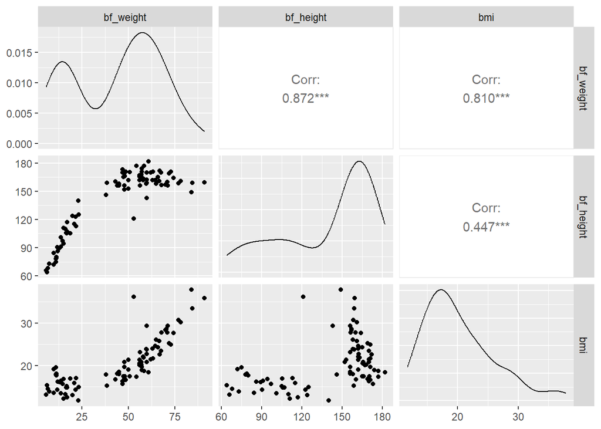

```r
### Inside the ggpairs function, include a subset of the variables that we want to include in the figure
ggpairs(data%>%
          select(bf_weight, bf_height, bmi))
```

## Think about it!

What relationships do you see in the data? There’s a lot of information here - can you figure out what is being plotted?

Multicollinearity (when two or more variables in a model are highly correlated) can lead to several problems in model estimation:

1. **Unstable model estimates**: when predictors are highly correlated, small changes in the data can cause large swings in the estimated coefficients.
2. **Difficult interpretation**: when predictors convey overlapping information, it becomes challenging to isolate the effect of each one on the outcome.
3. **Reduced predictive power**: While the model may fit the training data well, multicollinearity can hurt generalization to new data.

## Age and HIV status

Let’s look at the relationship between age and HIV status.

First, we need to modify the variable for HIV status, because it was just collected for the 0-8 subgroup and is missing for the adults.

```r
### We did this in the first portion of the workshop activity

data <- data%>%
  ### Create a new variable, "new_hiv_status"

  ### When the participant is in the 15 and older category AND the HIV status is missing, the value is positive

  mutate(new_hiv_status = case_when(age_cat == "15 and older" & bf_hivstatus == "" ~ "Positive",
  ### When that condition is NOT met (so for all the participants in the 0-8 category), retain the value of the bf_hivstatus variable
                                TRUE ~ bf_hivstatus))
```

Now, we can create a table of categorical age and HIV status:

```r
table(data$age_cat, data$new_hiv_status)%>%
  addmargins()
```

```
##
##                Negative Positive Unknown Sum
##   0-8                17        2      11  30
##   15 and older        0       59       0  59
##   Sum                17       61      11  89
```

100% of adults are living with HIV. This means there’s no variation in HIV status among adults - their HIV status is completely determined by age. This is known as **perfect separation** or between age and HIV status.

This is a problem for logistic regression modeling.

In logistic regression, each predictor should explain unique, independent information about the outcome. When one predictor (like age) perfectly predicts another (like HIV status), the model can’t tell which one is truly driving the relationship with the outcome. This can lead to:

- Unstable or infinite estimates
- Large standard errors
- Model convergence issues
- Misleading results

Currently, it doesn’t make sense to include both age and HIV status in the model with all participants.

# What subset to use moving forward?

In light of what we’ve investigated so far, we have a few options.

## 1. Just adults.

This would allow us to include CD4 in the model, because all adults are living with HIV.

```r
adult_subset <- data%>%
  filter(age_cat == "15 and older")
```

```r
sum(is.na(adult_subset$composite_cd4))
```

```
## [1] 2
```

```r
nrow(adult_subset)
```

```
## [1] 59
```

```r
57 / 59
```

```
## [1] 0.9661017
```

This variable is 96.6% complete; just 2 adults living with HIV are missing CD4 count.

## 2. Just children

This would allow us to include HIV status in the model.

```r
children_subset <- data%>%
  filter(age_cat == "0-8")
table(children_subset$stool_semiquant_bin, children_subset$bf_hivstatus, exclude = NULL)%>%
  addmargins()
```

```
##
##             Negative Positive Unknown Sum
##   Not Trace        3        0       3   6
##   Trace           14        2       8  24
##   Sum             17        2      11  30
```

However, only 2 participants are living with HIV, and both have a stool Xpert Ultra trace result. This could potentially lead to model fit issues.

## 3. Include both age categories

If we include all ages, we won’t be able to include HIV status because of the perfect separation we identified above. This is a limitation, because it will be difficult to tease out if the effect is due to HIV status or age.

## Think about it!

Moving forward in this workshop, we will just use the adult analytic cohort and include the CD4 count as a variable in the model.

However, what should we do differently for the manuscript?

Before proceeding with the analysis, make a few modifications.

```r
### Remove the 2 participants missing CD4 from the analysis
adult_subset <- adult_subset%>%
  filter(!is.na(composite_cd4))%>%
  ### Create a binary variable from CD4
  mutate(cd4_cat = ifelse(composite_cd4 < 200, "CD4 < 200", "CD4 >= 200"))
```

```r
### Create a categorical variable for nutritional status using BMI; sourced from the CDC

### https://www.cdc.gov/bmi/adult-calculator/bmi-categories.html

adult_subset <- adult_subset%>%
  mutate(nutritional_cat = case_when(bmi < 18.5 ~ "Underweight",
                                     bmi >= 18.5 & bmi < 25 ~ "Healthy weight",
                                     bmi >=25 & bmi < 30 ~ "Overweight",
                                     bmi >=30 ~ "Overweight"))
```

```r
### How many participants does this include?
nrow(adult_subset)
```

```
## [1] 57
```

```r
### What does our outcome - the newly created variable - look like?
table(adult_subset$stool_semiquant_bin, exclude = NULL)%>%
  addmargins()
```

```
##
## Not Trace     Trace       Sum
##        25        32        57
```

There are 57 participants in the adult subset. Of these, 32 have a trace result.

```r
32 / 57
```

```
## [1] 0.5614035
```

# Visualize the variables in relation to the outcome

Now, let’s investigate the relationship between this outcome and the variables we’re going to include in the model.

For each variable, plot the variable along with the outcome.

## BMI

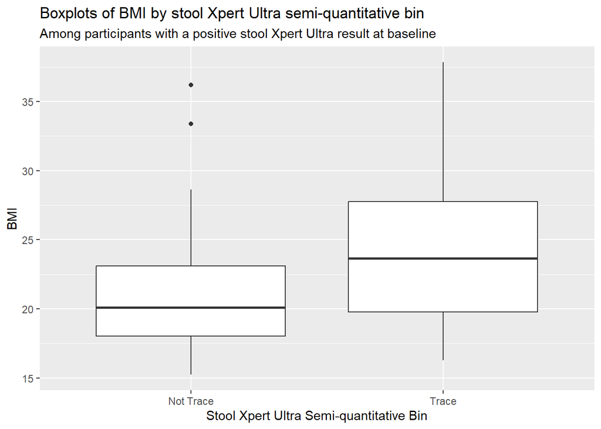

```r
ggplot(data = adult_subset, aes(x = stool_semiquant_bin, y = bmi))+
  geom_boxplot()+
  labs(x = "Stool Xpert Ultra Semi-quantitative Bin",
       y = "BMI",
       title = "Boxplots of BMI by stool Xpert Ultra semi-quantitative bin",
       subtitle = "Among participants with a positive stool Xpert Ultra result at baseline")
```

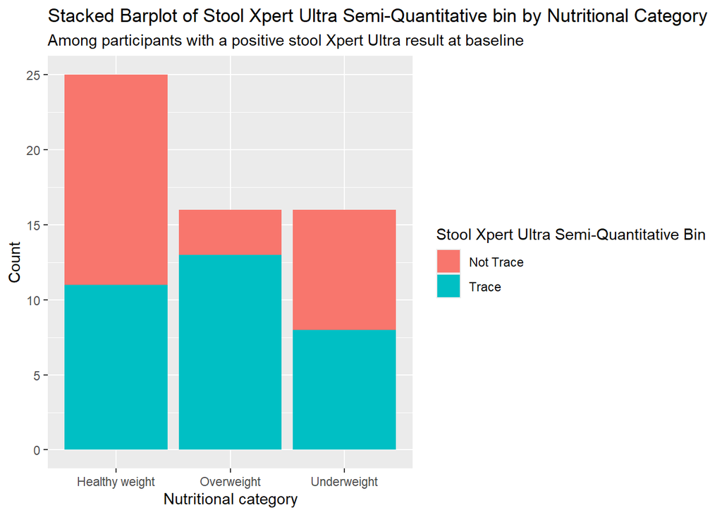

```r
ggplot(data = adult_subset, aes(x = nutritional_cat, fill = stool_semiquant_bin))+
  geom_bar()+
  labs(x = "Nutritional category",
       y = "Count",
       fill = "Stool Xpert Ultra Semi-Quantitative Bin",
       title = "Stacked Barplot of Stool Xpert Ultra Semi-Quantitative bin by Nutritional Category",
       subtitle = "Among participants with a positive stool Xpert Ultra result at baseline")
```

## Country

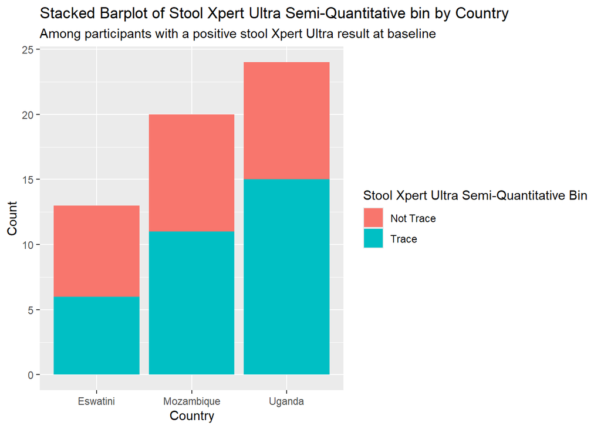

```r
ggplot(data = adult_subset, aes(x = rf_country, fill = stool_semiquant_bin))+
  geom_bar()+
  labs(x = "Country",
       y = "Count",
       fill = "Stool Xpert Ultra Semi-Quantitative Bin",
       title = "Stacked Barplot of Stool Xpert Ultra Semi-Quantitative bin by Country",
       subtitle = "Among participants with a positive stool Xpert Ultra result at baseline")
```

## Enrollment location

```r
table(adult_subset$rf_enrollocation, adult_subset$stool_semiquant_bin, exclude = NULL)%>%
  addmargins()
```

```
##
##              Not Trace Trace Sum
##   Inpatient          0     2   2
##   Outpatient        25    30  55
##   Sum               25    32  57
```

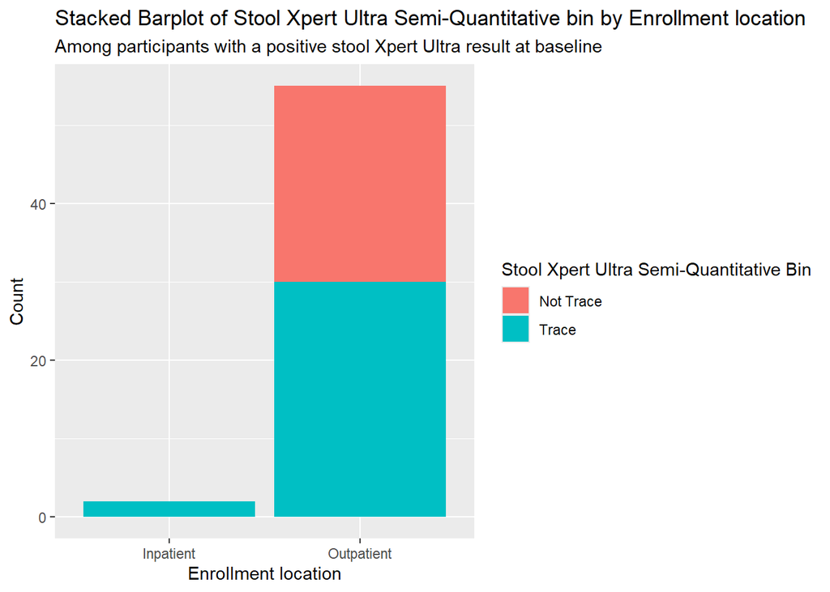

```r
ggplot(data = adult_subset, aes(x = rf_enrollocation, fill = stool_semiquant_bin))+
  geom_bar()+
  labs(x = "Enrollment location",
       y = "Count",
       fill = "Stool Xpert Ultra Semi-Quantitative Bin",
       title = "Stacked Barplot of Stool Xpert Ultra Semi-Quantitative bin by Enrollment location",
       subtitle = "Among participants with a positive stool Xpert Ultra result at baseline")
```

We can see that there are just **2** participants who were enrolled in an inpatient setting and the rest enrolled in an outpatient setting. We won’t include this in the final model because it will create some problems:

**Very small group size**: With just 2 inpatient participants, the model has very little adult_subset to reliably estimate the effect of being inpatient. Further, both of them have a result that is “Trace”.

**Unstable estimates**: The regression coefficient for the inpatient group will likely be highly unstable and imprecise, leading to wide confidence intervals or even convergence problems.

**Low statistical power**: With so few cases, it’s unlikely we’ll detect a meaningful association even if one exists.

**Potential overfitting**: Including rare categories can cause the model to fit noise rather than real patterns, hurting generalizability.

## Gender

```r
table(adult_subset$rf_gender, adult_subset$stool_semiquant_bin, exclude = NULL) %>%
  addmargins()
```

```
##
##          Not Trace Trace Sum
##   Female        14    21  35
##   Male          11    11  22
##   Sum           25    32  57
```

We’re going to pause here to introduce a new concept: **odds ratios**.

## Odds ratios

An **odds ratio (OR)** is a way to compare the **likelihood of something happening in one group compared to another**.

In this case, we’re comparing the likelihood of having a stool Xpert Ultra trace result between two groups - **females and males**.

### Step 1: What are “odds”?

The **odds** of an event are calculated as:

> odds = probability of the event happening ÷ probability of it not happening

Let’s calculate the odds for **females**:

- 21 had a trace result
- 14 did not

```r
21 / 14
```

```
## [1] 1.5
```

Now let’s calculate the odds for **males**:

- 11 had a trace result
- 11 did not

```r
11 / 11
```

```
## [1] 1
```

### Step 2: Calculate the Odds Ratio

The **odds ratio (OR)** compares the odds in females to the odds in males.

```r
(21 / 14) / (11 / 11)
```

```
## [1] 1.5
```

### Step 3: Interpretation

The odds of having a stool Xpert Ultra trace result are approximately **1.5 times higher in females than in males**. Here, males would be the **reference category**.

An odds ratio of **1** means that both groups have the same odds of experiencing the event.

An odds ratio **greater than 1** means that the group being compared has higher odds of the event happening than the reference group. In other words, the event is more likely in this group.

An odds ratio **less than 1** means that the group being compared has lower odds of the event happening than the reference group. In other words, the event is less likely in this group.

### Step 4. Connecting this to logistic regression

We can do this same calculation by fitting a **logistic regression model with one variable**.

```r
adult_subset <- adult_subset%>%
  ### First, create a variable - outcome - that is 1 if Trace, 0 if not. This is necessary to fit the model.
  mutate(outcome = ifelse(stool_semiquant_bin == "Trace", 1, 0))%>%
  ### By default, R chooses the first alphabetical category to be the reference category. However, often we want the OR > 1 to make it easier to interpret. Because the have already shown that the OR > 1 when the reference is Male, we convert to a factor and switch the order
  mutate(rf_gender = factor(rf_gender, levels = c("Male", "Female")))
```

```r
### Build the model!
logistic_regression_model <- glm(outcome ~ rf_gender, data = adult_subset, family = "binomial")
```

```r
summary(logistic_regression_model)
```

```
##
## Call:
## glm(formula = outcome ~ rf_gender, family = "binomial", data = adult_subset)
##
## Coefficients:
##                   Estimate Std. Error z value Pr(>|z|)
## (Intercept)     -1.042e-15  4.264e-01   0.000     1.00
## rf_genderFemale  4.055e-01  5.485e-01   0.739     0.46
##
## (Dispersion parameter for binomial family taken to be 1)
##
##     Null deviance: 78.157  on 56  degrees of freedom
## Residual deviance: 77.609  on 55  degrees of freedom
## AIC: 81.609
##
## Number of Fisher Scoring iterations: 4
```

There is a lot in this summary! We’ll learn more about some of the other values later, but let’s focus on the coefficient estimate for `rf_gender.`

We see `rf_genderFemale`. This let’s us know that the odds are for the female group, so we know the **reference group** must be male.

The estimate is 0.4055. A logistic regression model predicts the **log odds** rather than the odds themselves. This is because odds are bounded between 0 and infinity, which can cause difficulties with modeling. By taking the **log**, we transform the odds to a scale that ranges from negative infinity to infinity, making it easier to model with a linear equation.

However, the odds ratio is easier to interpret than the log odds.

To go from the **log odds** to the **odds ratio** we can exponentiate the coefficient estimate.

```r
exp(0.4055)
```

```
## [1] 1.500052
```

This is the same value we calculated above by hand (with a little bit of rounding differences)! This is what is going on “behind the scenes” of the function, and the same logic applies to a logistic regression model with multiple predictors.

Now, let’s pivot back to visualizing the relationship between the other variables and the outcome.

## Age

We are filtering to an analytic subset that is just adults.

It does not make sense to also include the `age_cat` variable in the model - all are “15 and older”.

Further, it doesn’t necessarily make sense to include the numeric age of those 15 and older.

## CD4

```r
table(adult_subset$cd4_cat, adult_subset$stool_semiquant_bin, exclude = NULL) %>%
  addmargins()
```

```
##
##              Not Trace Trace Sum
##   CD4 < 200         10     4  14
##   CD4 >= 200        15    28  43
##   Sum               25    32  57
```

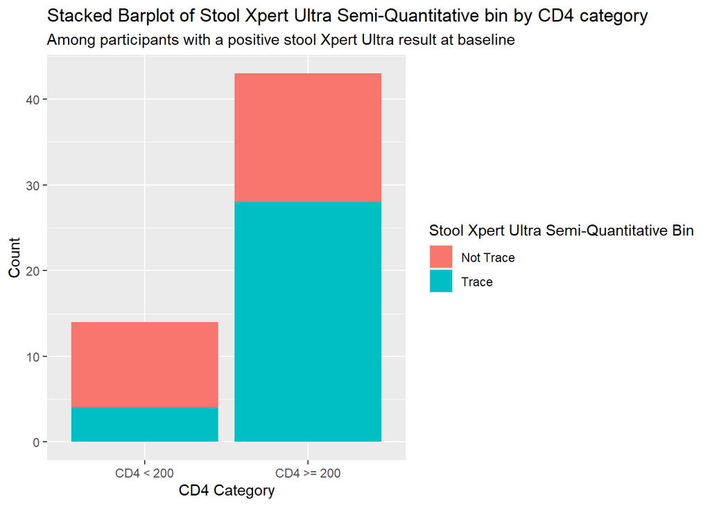

```r
ggplot(data = adult_subset, aes(x = cd4_cat, fill = stool_semiquant_bin))+
  geom_bar()+
  labs(x = "CD4 Category",
       y = "Count",
       fill = "Stool Xpert Ultra Semi-Quantitative Bin",
       title = "Stacked Barplot of Stool Xpert Ultra Semi-Quantitative bin by CD4 category",
       subtitle = "Among participants with a positive stool Xpert Ultra result at baseline")
```

## Think about it!

Discuss with someone near you - what does the above table and figure tell us about the relationship between categorical CD4 count and whether a stool Xpert Ultra result is trace or not?

## Try it!

Calculate the odds ratio for having a trace stool Xpert Ultra result for the group with a CD4 >=200 compared to the group with a CD4 < 200.

```r
### Calculate the OR by hand here
```

```r
### Use the lm() function here
```

```r
### Exponentiate the coefficient estimate from the model here
```

# Build the model

Include all the variables we investigated above in the final model.

```r
final_model <- glm(outcome ~ rf_country + rf_gender + nutritional_cat + cd4_cat, data = adult_subset, family = "binomial")
```

# Model diagnostics

The assumptions for logistic regression models are:

1. The outcome is binary (i.e. has two levels)
2. There are no extreme values or outliers
3. There are no highly correlated predictors
4. There is a linear relationship between the **log odds** of the outcome and each predictor value.

Let’s tackle these one at a time!

## 1. The outcome is binary

We have ensured that with the construction of our model, but to confirm:

```r
table(adult_subset$outcome)
```

```
##
##  0  1
## 25 32
```

## 2. There are no extreme values or outliers

To investigate this, we can look at the **standardized residuals** of the model.

**Residuals** are the difference between the observed outcome - in this case, 0 or 1 - and the predicted probability of the participant having a trace result.

```r
### Investigate outliers
adult_subset <- adult_subset%>%
  ### Create a variable that is the predicted probability of having a stool Xpert Ultra trace result - this ranges from 0 to 1
  mutate(predicted_probability = predict(final_model, type = "response"))%>%
  ### Create a variable for the residual - this is the difference between the outcome - either 0 or 1 - and the predicted probability
  mutate(residual = outcome - predicted_probability)%>%
  ### Calculate the standard deviation of the predicted probability
  mutate(standard_deviation = sqrt(predicted_probability * (1 - predicted_probability)))%>%
  ### Standardize the raw residual by the standard deviation so we can compare each point
  mutate(standardized_residual = residual / standard_deviation)%>%
  ### Include a variable with the generic index of the participant for plotting purposes
  mutate(generic_index = row_number())
```

What does the **residual** look like?

Notice that in this figure, the residual values are bound between -1 and 1.

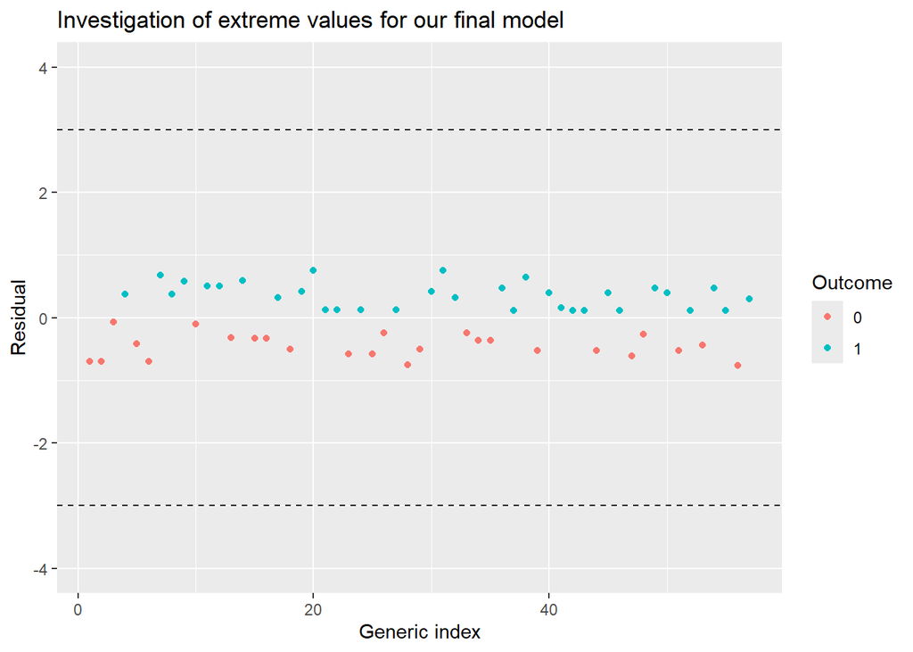

```r
ggplot(data = adult_subset, aes(x = generic_index, y = residual, color = as.factor(outcome))) +
  geom_point()+
  labs(x = "Generic index",
       y = "Residual",
       color = "Outcome",
       title = "Investigation of extreme values for our final model")+
  ylim(c(-4, 4))+
  geom_hline(yintercept = -3, lty = 2)+
  geom_hline(yintercept = 3, lty = 2)
```

What does the **standardized residual** look like?

Different predictions have different levels of uncertainty. For example, a prediction of 0.5 is more uncertain than a prediction of 0.95.

To fairly compare residuals across all predictions, we divide each residual by its expected variability — this gives us the standardized residual, which puts them all on the same scale. Standardized residuals help us identify which points are unusually far from what the model expected.

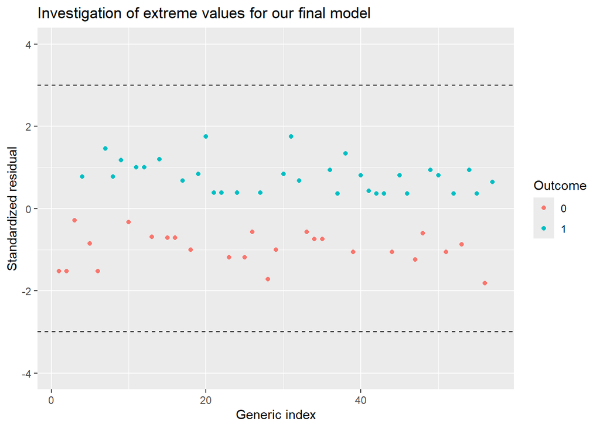

```r
ggplot(data = adult_subset, aes(x = generic_index, y = standardized_residual, color = as.factor(outcome))) +
  geom_point()+
  labs(x = "Generic index",
       y = "Standardized residual",
       color = "Outcome",
       title = "Investigation of extreme values for our final model")+
  ylim(c(-4, 4))+
  geom_hline(yintercept = -3, lty = 2)+
  geom_hline(yintercept = 3, lty = 2)
```

In both plots above, dashed lines are added at standardized residuals of -3 and 3. Any points that are more extreme than -3 and 3 are considered outliers and need to be investigated further and potentially removed from the model.

Everything looks good from the figure above!

## 3. There are no highly correlated predictors

We investigated this prior to building the model by looking at the relationship between the different predictors in the model.

However, a double-check is looking at the **variance inflation factor (VIF)**.

The VIF is calculated for each predictor to assess how much its variance is inflated due to correlation with other predictors.

**VIF = 1**: No correlation between a given predictor and the others.

**VIF between 1–5**: Low/moderate correlation — not usually a concern.

**VIF > 10**: High multicollinearity — we may want to remove or combine variables.

```r
# Calculate the VIF for each predictor
vif(final_model)
```

```
##                     GVIF Df GVIF^(1/(2*Df))
## rf_country      1.253482  2        1.058107
## rf_gender       1.138719  1        1.067108
## nutritional_cat 1.446320  2        1.096645
## cd4_cat         1.259341  1        1.122204
```

In this output, we can focus on the **GVIF^(1/(2*Df))** column. This is an adjusted VIF, which is appropriate to use because our model contains categorical variables.

All are near 1, so this is okay!

## 4. There is a linear relationship between the log odds of the outcome and each predictor value.

What does this mean? For continuous predictors, a one-unit increase should correspond to a consistent change in the log odds of the outcome.

We check this assumption because if the relationship is not linear, the model may be misspecified, leading to biased or misleading results.

However, all the predictors we included in our model are categorical, meaning they represent distinct groups or categories. For categorical variables, the model estimates separate effects for each category compared to a reference group. Since these effects are not based on a continuous scale but rather on group membership, the assumption of linearity in the log odds does not apply in the same way.

Therefore, with only categorical predictors, this linearity assumption is automatically met, and we don’t need additional checks or transformations for this assumption.

# Interpret the model

We can run the `summary()` function on the model to get more information on the model.

```r
summary(final_model)
```

```
##
## Call:
## glm(formula = outcome ~ rf_country + rf_gender + nutritional_cat +
##     cd4_cat, family = "binomial", data = adult_subset)
##
## Coefficients:
##                            Estimate Std. Error z value Pr(>|z|)
## (Intercept)                 -2.5338     1.2172  -2.082   0.0374 *
## rf_countryMozambique         1.0893     0.8607   1.266   0.2056
## rf_countryUganda             1.1933     0.8215   1.453   0.1463
## rf_genderFemale              0.3220     0.6392   0.504   0.6144
## nutritional_catOverweight    1.5982     0.8441   1.893   0.0583 .
## nutritional_catUnderweight   0.7520     0.7477   1.006   0.3145
## cd4_catCD4 >= 200            1.4562     0.7810   1.865   0.0622 .
## ---
## Signif. codes:  0 '***' 0.001 '**' 0.01 '*' 0.05 '.' 0.1 ' ' 1
##
## (Dispersion parameter for binomial family taken to be 1)
##
##     Null deviance: 78.157  on 56  degrees of freedom
## Residual deviance: 66.256  on 50  degrees of freedom
## AIC: 80.256
##
## Number of Fisher Scoring iterations: 4
```

## Call

The `call` output reminds us the arguments we passed to the function:

glm(formula = outcome ~ rf_country + rf_gender + nutritional_cat + cd4_cat, family = “binomial”, data = adult_subset)

## Estimate

The estimate column is the **log-odds**.

To better interpret this column, we can **exponentiate this** to get the odds ratio.

```r
exp(coef(final_model))
```

```
##                (Intercept)       rf_countryMozambique
##                 0.07935898                 2.97219096
##           rf_countryUganda            rf_genderFemale
##                 3.29805792                 1.37993615
##  nutritional_catOverweight nutritional_catUnderweight
##                 4.94403213                 2.12127391
##          cd4_catCD4 >= 200
##                 4.28964859
```

```r
exp(confint(final_model))
```

```
##                                  2.5 %     97.5 %
## (Intercept)                0.005794345  0.7201409
## rf_countryMozambique       0.582684501 17.9408043
## rf_countryUganda           0.691541888 18.2685287
## rf_genderFemale            0.391391000  4.9295332
## nutritional_catOverweight  1.043936712 30.9070934
## nutritional_catUnderweight 0.507969524  9.9621641
## cd4_catCD4 >= 200          1.003997550 22.6123961
```

## p-values

The final column includes p-values for each variable.

It is testing the hypothesis that the coefficient is different from 0, which corresponds to an odds ratio of 1 (in other words, that there is no association between the predictor and the log-odds of the outcome).

If the **p-value is less than 0.05**, we can conclude that there is an association between the predictor and the outcome.

In our model, none of the p-values are less than 0.05. So, we didn’t find evidence for any of the variables we included that they are significantly associated with a stool Xpert Ultra trace result.

## Additional outcome at the bottom

**AIC** is the Akaike Information Criterion and is used to compare different models. If we build different models, we can compare them using the AIC. A lower value is better.

**Deviance**

The **null deviance** is the amount of variability that is explained by the **null model** - no predictors, just the model intercept.

The **residual deviance** is the amount of variability that the full model explains.

# Supplementary analysis

As a follow-up to this model, we might want to know who initiated TB treatment, among adults with a positive stool Xpert Ultra result.

We might also want to know their outcomes!

## ATT initiation

First, let’s investigate the variable for ATT initiation.

```r
table(adult_subset$bf_startedatt, exclude = NULL)%>%
  addmargins()
```

```
##
##      No Yes Sum
##  33   1  23  57
```

If we use the `adult_subset`, it appears that we do not have information for 33 adults on whether they started ATT.

However, this is because the `adult_subset` is filtering to just the **baseline** form. This information was also calculated in the **ATT initiation** form.

So, read back in the original data in order to get the information on ATT initiation.

```r
data <- read.csv("C:/Users/u249135/OneDrive - Baylor College of Medicine/Teaching Materials/R-workshop/Workshop/Stool4TB Database for Abi.csv")
```

```r
### Filter to all participants who initiated on ATT; this is everyone who answered "Yes" for the bf_startedatt variable, regardless of the form
att_init_ids <- data%>%
  filter(bf_startedatt == "Yes")%>%
  pull(record_id)%>%
  unique()
### Create a variable in the adult subset that indicates whether someone initiated treatment or not
adult_subset <- adult_subset%>%
  mutate(att_initiation = ifelse(record_id %in% att_init_ids, "Initiated ATT", "Did not initiate ATT"))
```

```r
table(adult_subset$att_initiation, exclude = NULL)%>%addmargins()
```

```
##
## Did not initiate ATT        Initiated ATT                  Sum
##                   15                   42                   57
```

How is ATT initiation related to trace results?

```r
table(adult_subset$att_initiation, adult_subset$stool_semiquant_bin, exclude = NULL)%>%
  addmargins()
```

```
##
##                        Not Trace Trace Sum
##   Did not initiate ATT         3    12  15
##   Initiated ATT               22    20  42
##   Sum                         25    32  57
```

There are 15 participants who had a positive stool Xpert Ultra result yet did not start treatment.

Of the 15, 12 had a Trace positive result.

We can easily investigate what is going on with the particiapnts who do not have a trace stool Xpert Ultra result yet did not start treatment.

Let’s look at their other microbiologic results.

```r
adult_subset%>%
  filter(stool_semiquant_bin == "Not Trace" & att_initiation == "Did not initiate ATT")%>%
  select(record_id, rf_country, pe_stoolsemiresult, pe_lamresult, pe_finalculturesult, pe_xpertresult)
```

```
##   record_id rf_country pe_stoolsemiresult pe_lamresult pe_finalculturesult
## 1 4TB-2-182 Mozambique           Very low     Negative           No growth
## 2 4TB-2-195 Mozambique                Low     Negative           No growth
## 3 4TB-3-052     Uganda           Very low     Negative           No growth
##     pe_xpertresult
## 1 MTB Not Detected
## 2     MTB Detected
## 3 MTB Not Detected
```

## Outcome

Similar to how we had to add in the ATT initiation variable, we need to create a variable for outcome because this is not found in the baseline form.

```r
temp_outcomes <- data%>%
  filter(redcap_event_name == "M6 post ATT")%>%
  select(record_id, po_ttoutcome)

### This is a new function - we want to join our adult_subest with the outcomes, by participant ID
adult_subset <- left_join(adult_subset%>%select(-c(po_ttoutcome)), temp_outcomes, by = "record_id")
```

Look at the association between the treatment outcome and the stool Xpert Ultra result:

```r
table(adult_subset$po_ttoutcome, adult_subset$stool_semiquant_bin, exclude = NULL)%>%
  addmargins()
```

```
##
##                       Not Trace Trace Sum
##   Cure                       15    16  31
##   Death                       1     0   1
##   Transfer out                2     1   3
##   Treatment completed         2     1   3
##   Treatment failed            1     0   1
##   <NA>                        4    14  18
##   Sum                        25    32  57
```

This may be something to revisit - it appears that 18 participants do not have an outcome reported; this could be the case if the outcome is just for those on ATT.

# Discussion of results

1. What additional analysis should be included in this manuscript?
2. Are any of the results of the model surprising?
3. What are some of the limitations of our results?
4. What are some next steps were should take?